# Homework 6

Darius Arasteh

2026-01-27

## Instructions

Answer the following questions and/or complete the exercises in RMarkdown. Please embed all of your code and push the final work to your repository. Your report should be organized, clean, and run free from errors. Remember, you must remove the `#` for any included code chunks to run.

## Load the tidyverse

```r
library("tidyverse")
library("janitor")
```

## Data

For this assignment, we will use data from a study on vertebrate community composition and impacts from defaunation in [Gabon, Africa](https://en.wikipedia.org/wiki/Gabon). One thing to notice is that the data include 24 separate transects. Each transect represents a path through different forest management areas.

Reference: Koerner SE, Poulsen JR, Blanchard EJ, Okouyi J, Clark CJ. Vertebrate community composition and diversity declines along a defaunation gradient radiating from rural villages in Gabon. *Journal of Applied Ecology*. 2016. A description of the variables is included inside the data folder.

**1. Load `IvindoData_DryadVersion.csv` and store it as a new object called `gabon`.**

```r
getwd()
```

```
## [1] "C:/Users/daras/Desktop/BIS15L_W26_darasteh/lab6"
```

```r
setwd("data")
gabon <- read.csv("IvindoData_DryadVersion.csv")%>%clean_names()
```

**2. Use one or more of the summary functions you have learned to get an idea of the structure of the data.**

```r
summary(gabon)
```

```
##   transect_id       distance        hunt_cat         num_households
##  Min.   : 1.00   Min.   : 2.700   Length:24          Min.   :13.00
##  1st Qu.: 5.75   1st Qu.: 5.668   Class :character   1st Qu.:24.75
##  Median :14.50   Median : 9.720   Mode  :character   Median :29.00
##  Mean   :13.50   Mean   :11.879                      Mean   :37.88
##  3rd Qu.:20.25   3rd Qu.:17.683                      3rd Qu.:54.00
##  Max.   :27.00   Max.   :26.760                      Max.   :73.00
##    land_use            veg_rich       veg_stems       veg_liana
##  Length:24          Min.   :10.88   Min.   :23.44   Min.   : 4.750
##  Class :character   1st Qu.:13.10   1st Qu.:28.69   1st Qu.: 9.033
##  Mode  :character   Median :14.94   Median :32.45   Median :11.940
##                     Mean   :14.83   Mean   :32.80   Mean   :11.040
##                     3rd Qu.:16.54   3rd Qu.:37.08   3rd Qu.:13.250
##                     Max.   :18.75   Max.   :47.56   Max.   :16.380
##     veg_dbh        veg_canopy    veg_understory     ra_apes
##  Min.   :28.45   Min.   :2.500   Min.   :2.380   Min.   : 0.000
##  1st Qu.:40.65   1st Qu.:3.250   1st Qu.:2.875   1st Qu.: 0.000
##  Median :43.90   Median :3.430   Median :3.000   Median : 0.485
##  Mean   :46.09   Mean   :3.469   Mean   :3.020   Mean   : 2.045
##  3rd Qu.:50.58   3rd Qu.:3.750   3rd Qu.:3.167   3rd Qu.: 3.815
##  Max.   :76.48   Max.   :4.000   Max.   :3.880   Max.   :12.930
##     ra_birds      ra_elephant       ra_monkeys      ra_rodent
##  Min.   :31.56   Min.   :0.0000   Min.   : 5.84   Min.   :1.060
##  1st Qu.:52.51   1st Qu.:0.0000   1st Qu.:22.70   1st Qu.:2.047
##  Median :57.90   Median :0.3600   Median :31.74   Median :3.230
##  Mean   :58.64   Mean   :0.5450   Mean   :31.30   Mean   :3.278
##  3rd Qu.:68.17   3rd Qu.:0.8925   3rd Qu.:39.88   3rd Qu.:4.093
##  Max.   :85.03   Max.   :2.3000   Max.   :54.12   Max.   :6.310
##   ra_ungulate     rich_all_species evenness_all_species diversity_all_species
##  Min.   : 0.000   Min.   :15.00    Min.   :0.6680       Min.   :1.966
##  1st Qu.: 1.232   1st Qu.:19.00    1st Qu.:0.7542       1st Qu.:2.248
##  Median : 2.545   Median :20.00    Median :0.7760       Median :2.316
##  Mean   : 4.166   Mean   :20.21    Mean   :0.7699       Mean   :2.310
##  3rd Qu.: 5.157   3rd Qu.:22.00    3rd Qu.:0.8083       3rd Qu.:2.429
##  Max.   :13.860   Max.   :24.00    Max.   :0.8330       Max.   :2.566
##  rich_bird_species evenness_bird_species diversity_bird_species
##  Min.   : 8.00     Min.   :0.5590        Min.   :1.162
##  1st Qu.:10.00     1st Qu.:0.6825        1st Qu.:1.603
##  Median :11.00     Median :0.7220        Median :1.680
##  Mean   :10.33     Mean   :0.7137        Mean   :1.661
##  3rd Qu.:11.00     3rd Qu.:0.7722        3rd Qu.:1.784
##  Max.   :13.00     Max.   :0.8240        Max.   :2.008
##  rich_mammal_species evenness_mammal_species diversity_mammal_species
##  Min.   : 6.000      Min.   :0.6190          Min.   :1.378
##  1st Qu.: 9.000      1st Qu.:0.7073          1st Qu.:1.567
##  Median :10.000      Median :0.7390          Median :1.699
##  Mean   : 9.875      Mean   :0.7477          Mean   :1.698
##  3rd Qu.:11.000      3rd Qu.:0.7847          3rd Qu.:1.815
##  Max.   :12.000      Max.   :0.8610          Max.   :2.065
```

**3. Clean the data as necessary following the conventions from lab 6.**

```r
gabon%>%
  clean_names()
```

```
##    transect_id distance hunt_cat num_households land_use veg_rich veg_stems
## 1            1     7.14 Moderate             54     Park    16.67     31.20
## 2            2    17.31     None             54     Park    15.75     37.44
## 3            2    18.32     None             29     Park    16.88     32.33
## 4            3    20.85     None             29  Logging    12.44     29.39
## 5            4    15.95     None             29     Park    17.13     36.00
## 6            5    17.47     None             29     Park    16.50     29.22
## 7            6    24.06     None             29     Park    14.75     31.22
## 8            7    19.81     None             54  Logging    13.25     32.56
## 9            8     5.78     High             25  Neither    12.63     23.67
## 10           9     5.13     High             73  Logging    16.00     27.11
## 11          13     6.61 Moderate             46  Logging    12.38     23.44
## 12          14     8.23 Moderate             56  Logging    15.75     30.22
## 13          15     2.70     High             46  Neither    10.88     25.44
## 14          16     6.10 Moderate             36  Logging    14.63     39.11
```

[output cut: 135 more lines]

**4. Use `mutate()` Change the variables `HuntCat`, `LandUse`, and `TransectID` to factors. Be sure to store the output as a new dataframe and use it for the remaining questions.**

```r
gabon%>%
  mutate(hunt_cat=as.factor(hunt_cat))%>%
  mutate(land_use=as.factor(land_use))%>%
  mutate(transect_id=as.factor(transect_id))
```

```
##    transect_id distance hunt_cat num_households land_use veg_rich veg_stems
## 1            1     7.14 Moderate             54     Park    16.67     31.20
## 2            2    17.31     None             54     Park    15.75     37.44
## 3            2    18.32     None             29     Park    16.88     32.33
## 4            3    20.85     None             29  Logging    12.44     29.39
## 5            4    15.95     None             29     Park    17.13     36.00
## 6            5    17.47     None             29     Park    16.50     29.22
## 7            6    24.06     None             29     Park    14.75     31.22
## 8            7    19.81     None             54  Logging    13.25     32.56
## 9            8     5.78     High             25  Neither    12.63     23.67
## 10           9     5.13     High             73  Logging    16.00     27.11
## 11          13     6.61 Moderate             46  Logging    12.38     23.44
## 12          14     8.23 Moderate             56  Logging    15.75     30.22
## 13          15     2.70     High             46  Neither    10.88     25.44
## 14          16     6.10 Moderate             36  Logging    14.63     39.11
```

[output cut: 135 more lines]

**5. Make a plot that shows the number of transects for each land use type.**

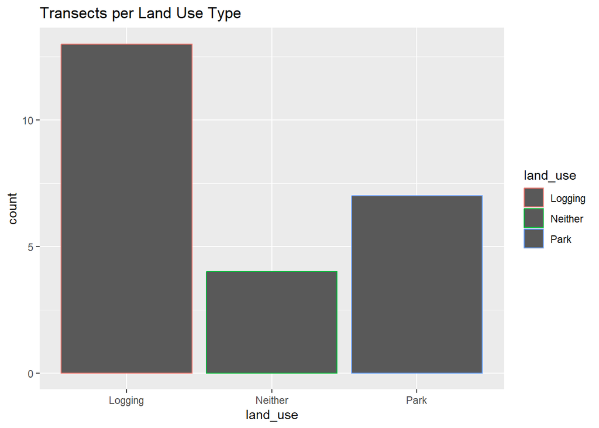

```r
gabon%>%
ggplot( #specifies the data
  mapping=aes(x=land_use))+ #map the aesthetics
  geom_bar(mapping=aes(color=land_use))+
  labs(title= "Transects per Land Use Type")
```

**6. How does vegetation richness compare among land use types?**

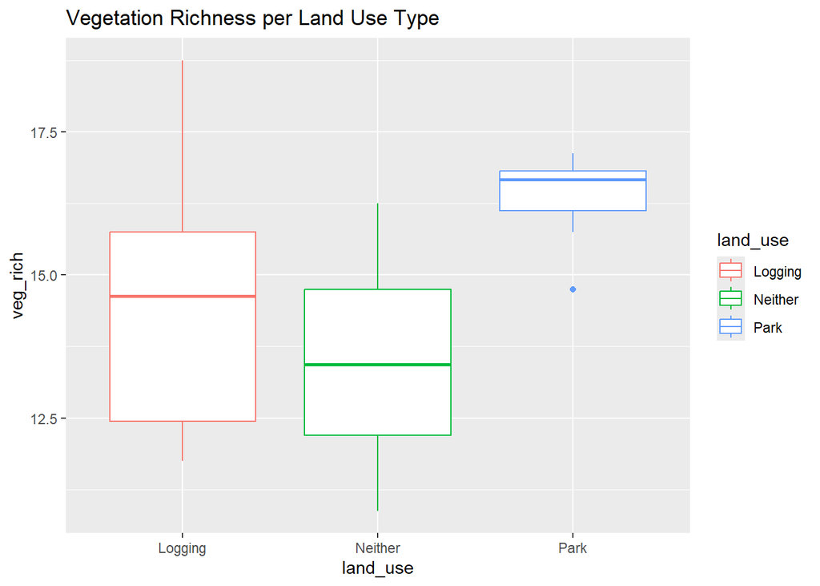

```r
gabon%>%
ggplot( #specifies the data
  mapping=aes(x=land_use,y=veg_rich))+ #map the aesthetics
  geom_boxplot(mapping=aes(color=land_use))+
  labs(title= "Vegetation Richness per Land Use Type")
```

**7. For which land use type (national parks, logging, or neither) is average all species diversity the greatest?**

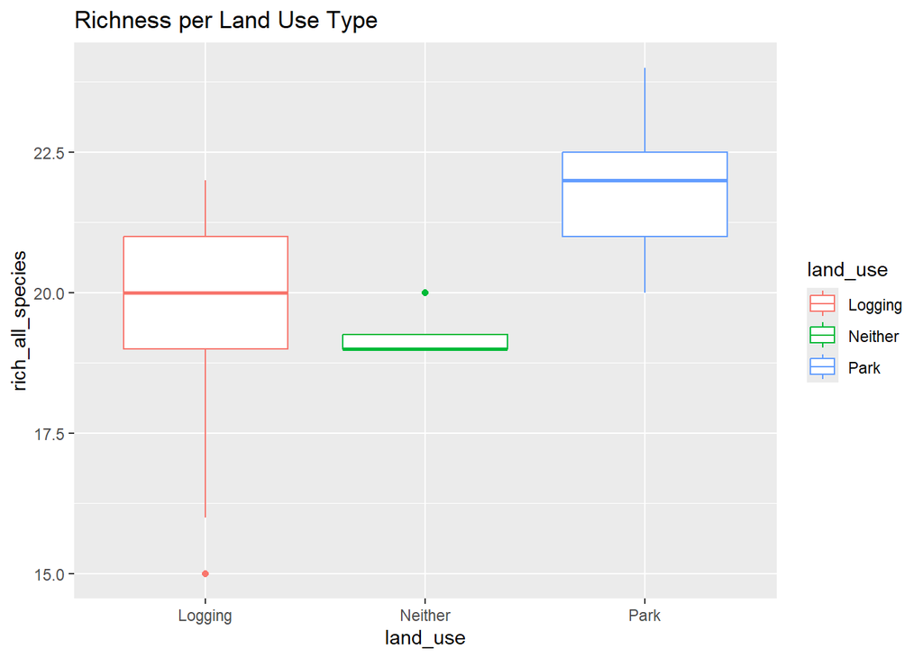

```r
gabon%>%
ggplot( #specifies the data
  mapping=aes(x=land_use,y=rich_all_species))+ #map the aesthetics
  geom_boxplot(mapping=aes(color=land_use))+
  labs(title= "Richness per Land Use Type")
```

**8. Is there a relationship between vegetation richness and mammal species richness?**

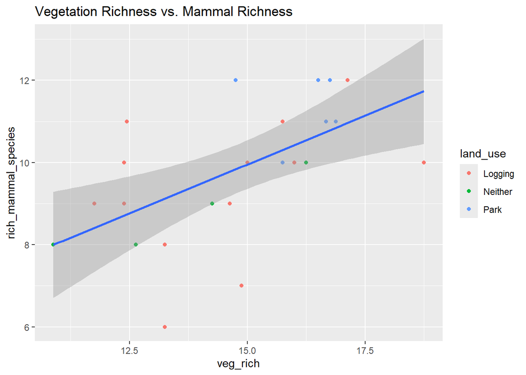

```r
gabon%>%
ggplot( #specifies the data
  mapping=aes(x=veg_rich,y=rich_mammal_species))+ #map the aesthetics
  geom_point(mapping=aes(color=land_use))+
  labs(title= "Vegetation Richness vs. Mammal Richness")+
  geom_smooth(method=lm, se=T)
```

**9. Use `filter` to find all transects that have greater than 15 tree species or a breast height diameter between 50 and 60cm.**

```r
gabon%>%
  filter(veg_rich>15 | (veg_dbh<60 & veg_dbh>50))
```

```
##    transect_id distance hunt_cat num_households land_use veg_rich veg_stems
## 1            1     7.14 Moderate             54     Park    16.67     31.20
## 2            2    17.31     None             54     Park    15.75     37.44
## 3            2    18.32     None             29     Park    16.88     32.33
## 4            4    15.95     None             29     Park    17.13     36.00
## 5            5    17.47     None             29     Park    16.50     29.22
## 6            6    24.06     None             29     Park    14.75     31.22
## 7            9     5.13     High             73  Logging    16.00     27.11
## 8           14     8.23 Moderate             56  Logging    15.75     30.22
## 9           15     2.70     High             46  Neither    10.88     25.44
## 10          17     3.83     High             19  Neither    14.25     32.56
## 11          21     5.14     High             24  Neither    16.25     34.89
## 12          22     5.33     High             13  Logging    17.13     41.56
## 13          24    26.76     None             29     Park    16.75     37.33
## 14          26    11.21 Moderate             73  Logging    18.75     39.11
```

[output cut: 75 more lines]

**10.Which transects and land use types have more than 10 tree species and 10 mammal species? Use `arrange()` to sort by the number of tree species.**

```r
gabon %>%
  filter(veg_rich>10 & rich_mammal_species>10) %>%
  arrange(veg_rich)
```

```
##   transect_id distance hunt_cat num_households land_use veg_rich veg_stems
## 1           3    20.85     None             29  Logging    12.44     29.39
## 2           6    24.06     None             29     Park    14.75     31.22
## 3          14     8.23 Moderate             56  Logging    15.75     30.22
## 4           5    17.47     None             29     Park    16.50     29.22
## 5           1     7.14 Moderate             54     Park    16.67     31.20
## 6          24    26.76     None             29     Park    16.75     37.33
## 7           2    18.32     None             29     Park    16.88     32.33
## 8           4    15.95     None             29     Park    17.13     36.00
## 9          22     5.33     High             13  Logging    17.13     41.56
##   veg_liana veg_dbh veg_canopy veg_understory ra_apes ra_birds ra_elephant
## 1      9.78   36.62       3.75           2.75   12.93    59.29        0.56
## 2      8.38   51.22       4.00           2.38    3.78    42.66        1.11
## 3     14.13   52.12       3.57           2.86    0.46    66.56        0.52
## 4     12.88   44.07       2.50           3.00    2.48    38.64        0.00
```

[output cut: 45 more lines]

## Knit and Upload

Please knit your work as an .html file and upload to Canvas. Homework is due before the start of the next lab. No late work is accepted. Make sure to use the formatting conventions of RMarkdown to make your report neat and clean!